##### The follwoing report is a compilation of the analysis done by me as a part of the 'wrangle and analyze data' project of the DAND programme offered by 'UDACITY'.

# Overview:

[figure not shown]

### In this project we have analyzed the data about *'WeRateDogs'* - a twitter account that rates the pictures/videos of your dogs. The have a fixed rating standard- The numerator of the rating is almost never less than 10 (Because they are DOGS!!!) and the denominator is always 10.The analysis of this dataset was carried after extensively wrangling the dataset(s).

# Analysis:

## 1.

## General analysis of the df_archive dataframe:

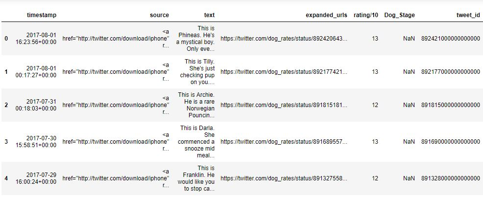

- **The average rating given out by the twitter account is 12.875.**
- **The minimum and maximum ratings are 10 and 1776 respectively.**

## 2.

### General analysis of the df_pred dataframe:

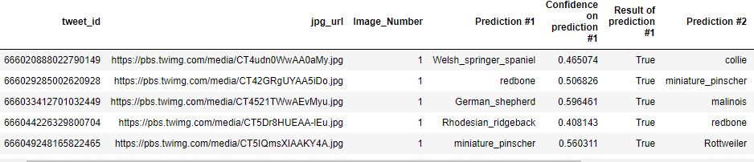

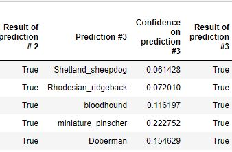

## 3.

### General analysis of the df_tweepy:

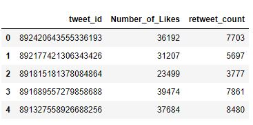

- **The minimum and maximum number of likes is 0 and 156164 respectively.**
- **The minimum and maximum number of retweets is 1 and 77780 respectively.**
- **The average number of likes for a tweet is 7554.39.**
- **The average number of retweets for a tweet is 2703.41**

### What is a retweet on twitter?

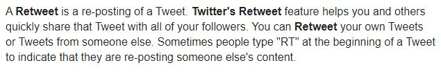

## 4.

### Observing the spread of various columns in df_pred dataframe:

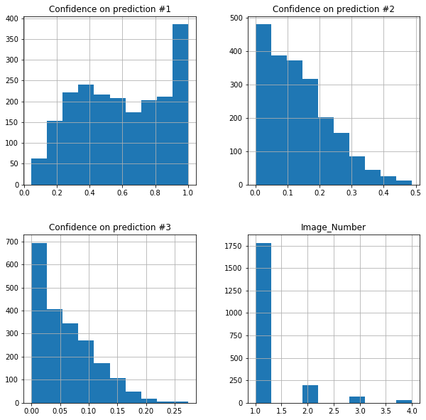

- **The Confidence on prediction #1 column has a left skewed spread.**
- **The rest of the histograms appear to be right-skewed.**
- **Our predicting model has the highest confidence in its 1st prediction.**
- **The confidence of the model goes on decreasing as the prediction number increases.**
- **Majority of times, the first image is the correct image from all the images present on the respective webpage.**

## 5.

### Observing the correlation between the confidence of the model on its various predictions:

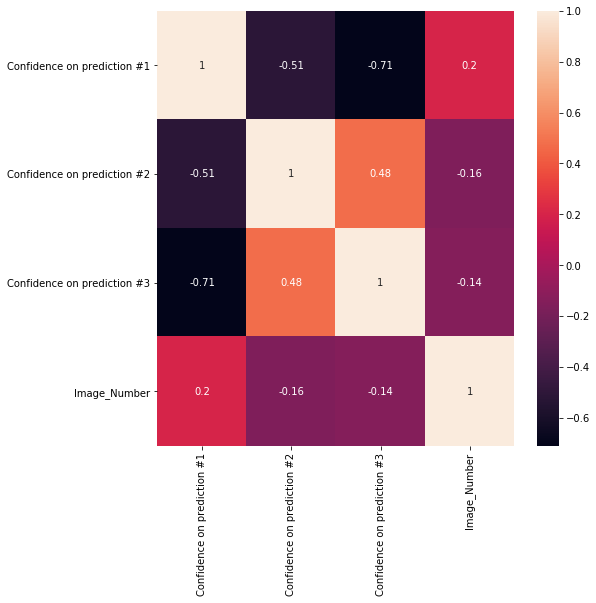

## 6.

### Observing the correlation between the number of likes and retweets that a tweet gets:

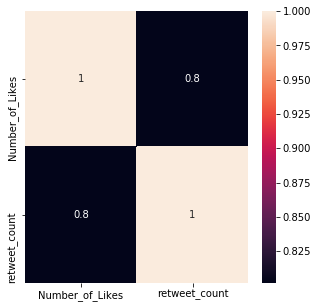

## 7. Proportion of correct predictions by the model.

- **73.8% of the first predictions made by the model are correct.**
- **74.8% of the second predictions made by the model are correct.**
- **72.2% of the third predictions made by the model are correct.**

#### PS: In the df_pred dataframe, multiple predictions are true for a single entry because a particular dog can be a mix-breed and the model might have picked the breed with most dominant traits in the first prediction, the breed with lesser dominant traits in the second prediction and so on. That is the reason why the above percentages do not add up to 100.

# Conclusions:

- **As the number of likes on a tweet increases, the number of retweets increases and vice-versa.**
- **The second prediction of the model makes the highest percentage of correct predictions.**
- **Majority of the times, the model has the highest confidence on its first prediction.**

# Limitation of the analysis:

### Since we could not merge the three dataframes into one, we could not analyze some relationships like 'number of likes and ratings', ' number of retweets and ratings'.